# Diamond Prices 2022

William Lovejoy

7/28/2022

```r
library(tidyverse)
library(scales)
library(ggridges)
library(equatiomatic)
library(cowplot)
library(caret)
library(arm)
library(car)
```

```r
df <- read.csv("C:\\Users\\William Lovejoy\\Documents\\Codes\\R\\DataScience\\Diamonds Prices2022.csv")
df$color <- factor(as.factor(df$color), levels = c("J", "I", "H", "G", "F",
                                                   "E", "D"))
df$clarity <- factor(as.factor(df$clarity), levels = c("I1", "SI2", "SI1",
                                                       "VS2", "VS1", "VVS2",
                                                       "VVS1", "IF"))
df$cut <- factor(as.factor(df$cut), levels = c("Fair", "Good", "Very Good",
                                               "Premium", "Ideal"))
glimpse(df)
```

```
## Rows: 53,943
## Columns: 11
## $ X       <int> 1, 2, 3, 4, 5, 6, 7, 8, 9, 10, 11, 12, 13, 14, 15, 16, 17, 18,…
## $ carat   <dbl> 0.23, 0.21, 0.23, 0.29, 0.31, 0.24, 0.24, 0.26, 0.22, 0.23, 0.…
## $ cut     <fct> Ideal, Premium, Good, Premium, Good, Very Good, Very Good, Ver…
## $ color   <fct> E, E, E, I, J, J, I, H, E, H, J, J, F, J, E, E, I, J, J, J, I,…
## $ clarity <fct> SI2, SI1, VS1, VS2, SI2, VVS2, VVS1, SI1, VS2, VS1, SI1, VS1, …
## $ depth   <dbl> 61.5, 59.8, 56.9, 62.4, 63.3, 62.8, 62.3, 61.9, 65.1, 59.4, 64…
## $ table   <dbl> 55, 61, 65, 58, 58, 57, 57, 55, 61, 61, 55, 56, 61, 54, 62, 58…
## $ price   <int> 326, 326, 327, 334, 335, 336, 336, 337, 337, 338, 339, 340, 34…
## $ x       <dbl> 3.95, 3.89, 4.05, 4.20, 4.34, 3.94, 3.95, 4.07, 3.87, 4.00, 4.…
## $ y       <dbl> 3.98, 3.84, 4.07, 4.23, 4.35, 3.96, 3.98, 4.11, 3.78, 4.05, 4.…
## $ z       <dbl> 2.43, 2.31, 2.31, 2.63, 2.75, 2.48, 2.47, 2.53, 2.49, 2.39, 2.…
```

We load in our diamond price dataset, and then convert the cut, clarity, and color variables to factors. We’ll also take this opportunity to set our factor levels from bottom to top. So color “D” is the highest, clarity “IF” is the clearest, and cut “Ideal” is the best. This will make it so all graphs with these variables put the highest ranked levels at the top unless otherwise stated.

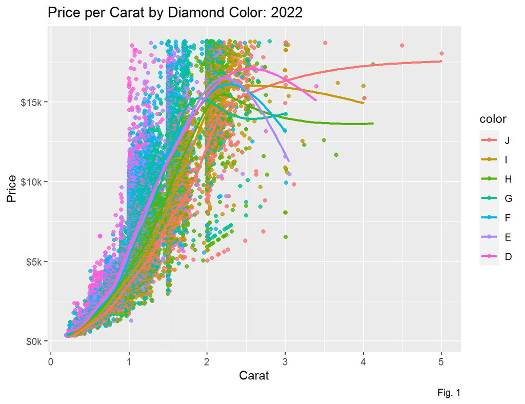

```r
df %>%
  ggplot(aes(x = carat, y = price, group = color, color = color)) +
  geom_point(position = "jitter", alpha = .8) + geom_smooth(se = FALSE) +
  scale_y_continuous(labels = label_number(prefix = "$", suffix = "k",
                                           scale = 1 / 1e3)) +
  labs(title = "Price per Carat by Diamond Color: 2022", x = "Carat",
       y = "Price", caption = "Fig. 1")
```

We can see here a generally positive relationship with diamond caret and diamond price. We can also see that the slope of the lines for each diamond color category is steeper as the diamonds color improves.

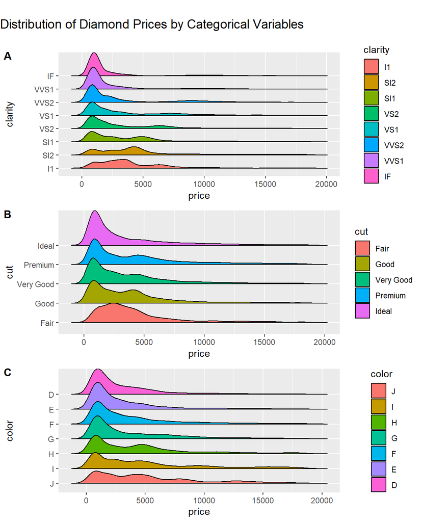

```r
priceByClarity <- df %>%
  ggplot(aes(x = price, y = clarity, fill = clarity)) + geom_density_ridges2() +
  scale_color_brewer(palette = "Dark2")

priceByCut <- df %>%
  ggplot(aes(x = price, y = cut, fill = cut)) + geom_density_ridges2() +
  scale_color_brewer(palette = "Dark2")

priceByColor <- df %>%
  ggplot(aes(x = price, y = color, fill = color)) + geom_density_ridges2() +
  scale_color_brewer(palette = "Dark2")

title <- ggdraw() +
  draw_label(
  "Distribution of Diamond Prices by Categorical Variables", x = 0, hjust = 0,
  size = 14)

plot_cols <- plot_grid(priceByClarity, priceByCut, priceByColor, ncol = 1,
                       align = "v", labels = c("A", "B", "C"), label_size = 12)

plot_grid(title, plot_cols, rel_heights = c(0.1,1), ncol = 1, align = "v")
```

As we break down our categorical variables, we can again see that the higher valued the factor, the more dense the price distribution is. Lower rated factors such as “J” coloring, “Fair” cuts, and “I1” clarity have a much wider spread. A large reason for this, if we look back at Fig. 1, is because diamonds with these poor qualities tend to have larger carats.

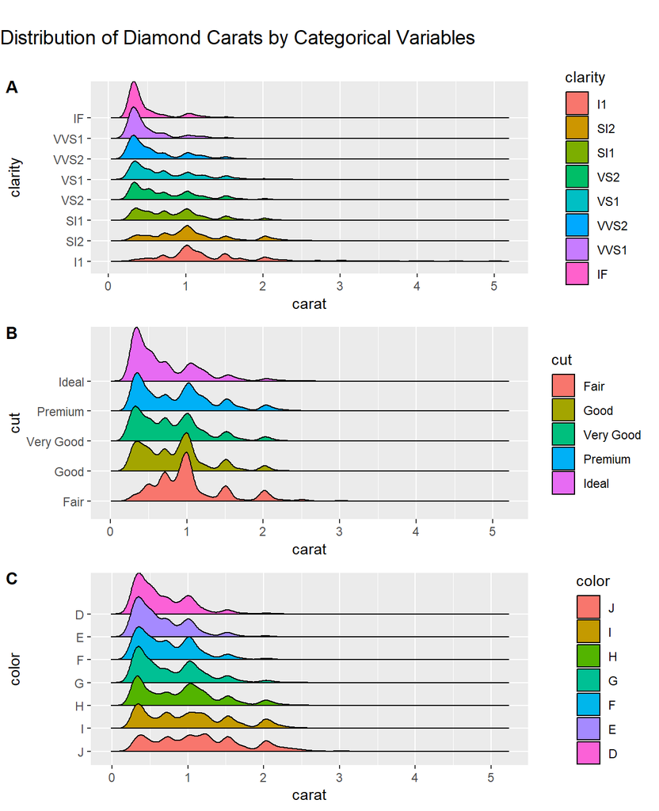

```r
caratByClarity <- df %>%
  ggplot(aes(x = carat, y = clarity, fill = clarity)) + geom_density_ridges2() +
  scale_color_brewer(palette = "Dark2")

caratByCut <- df %>%
  ggplot(aes(x = carat, y = cut, fill = cut)) + geom_density_ridges2() +
  scale_color_brewer(palette = "Dark2")

caratByColor <- df %>%
  ggplot(aes(x = carat, y = color, fill = color)) + geom_density_ridges2() +
  scale_color_brewer(palette = "Dark2")

title <- ggdraw() +
  draw_label(
  "Distribution of Diamond Carats by Categorical Variables", x = 0, hjust = 0,
  size = 14)

plot_cols_2 <- plot_grid(caratByClarity, caratByCut, caratByColor, ncol = 1,
                         align = "v", labels = c("A", "B", "C"),
                         label_size = 12)

plot_grid(title, plot_cols_2, rel_heights = c(0.1,1), ncol = 1, align = "v")
```

As we can see, the lower quality a diamond is, the more spread out it is in terms of carat distribution.

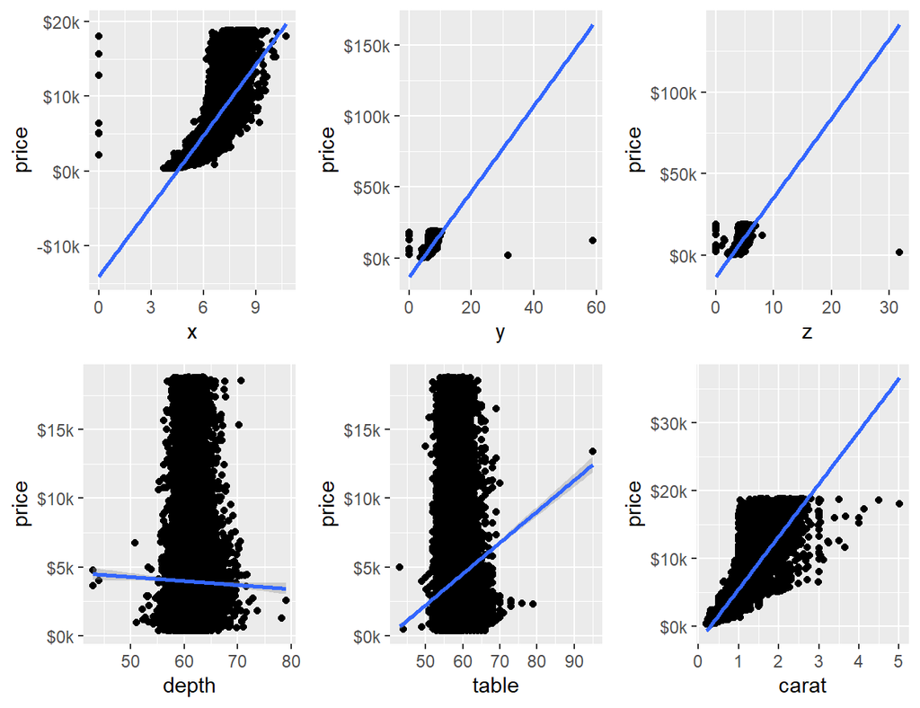

```r
priceByX <- df %>%
  ggplot(aes(x = x, y = price)) + geom_point(position = "jitter") +
  geom_smooth(method = "lm") +
  scale_y_continuous(labels = label_number(prefix = "$", suffix = "k",
                                           scale = 1 / 1e3))

priceByY <- df %>%
  ggplot(aes(x = y, y = price)) + geom_point(position = "jitter") +
  geom_smooth(method = "lm") +
  scale_y_continuous(labels = label_number(prefix = "$", suffix = "k",
                                           scale = 1 / 1e3))

priceByZ <- df %>%
  ggplot(aes(x = z, y = price)) + geom_point(position = "jitter") +
  geom_smooth(method = "lm") +
  scale_y_continuous(labels = label_number(prefix = "$", suffix = "k",
                                           scale = 1 / 1e3))

priceByDepth <- df %>%
  ggplot(aes(x = depth, y = price)) + geom_point(position = "jitter") +
  geom_smooth(method = "lm") +
  scale_y_continuous(labels = label_number(prefix = "$", suffix = "k",
                                           scale = 1 / 1e3))

priceByTable <- df %>%
  ggplot(aes(x = table, y = price)) + geom_point(position = "jitter") +
  geom_smooth(method = "lm") +
  scale_y_continuous(labels = label_number(prefix = "$", suffix = "k",
                                           scale = 1 / 1e3))

priceByCarat <- df %>%
  ggplot(aes(x = carat, y = price)) + geom_point(position = "jitter") +
  geom_smooth(method = "lm") +
  scale_y_continuous(labels = label_number(prefix = "$", suffix = "k",
                                           scale = 1 / 1e3))

plot_grid(priceByX, priceByY, priceByZ,
          priceByDepth, priceByTable, priceByCarat, ncol = 3)
```

A quick look at the scatter plots comparing the other measured variables to price shows us some fairly strong correlations with all of them except depth. However, if we calculate correlation values for all non-categorical factors, we can take all with a value over 0.75 to craft our linear regression model.

```r
correlations <- cor(df[, c(2, 6:11)])
highlyCorrelated <- findCorrelation(correlations, cutoff = .75)
cat("Highly Correlated variables (>.75) are:", names(df[, -highlyCorrelated]))
```

```
## Highly Correlated variables (>.75) are: carat cut color price x y z
```

```r
model <- lm(log(price) ~ carat + x + y + z + cut + color, data = df)
display(model)
```

```
## lm(formula = log(price) ~ carat + x + y + z + cut + color, data = df)
##              coef.est coef.se
## (Intercept)   1.39     0.02
## carat        -0.47     0.01
## x             0.96     0.01
## y             0.02     0.00
## z             0.19     0.01
## cutGood       0.11     0.01
## cutVery Good  0.15     0.01
## cutPremium    0.11     0.01
## cutIdeal      0.20     0.01
## colorI        0.13     0.01
## colorH        0.24     0.01
## colorG        0.38     0.01
## colorF        0.40     0.01
## colorE        0.41     0.01
## colorD        0.44     0.01
## ---
## n = 53943, k = 15
## residual sd = 0.25, R-Squared = 0.94
```

Our model gives us a strong R<sup>2</sup> of 0.94 after log transforming our prices. And by looking at our QQ and Residual KDE plots, we can see fat tails but very little skew in our data.

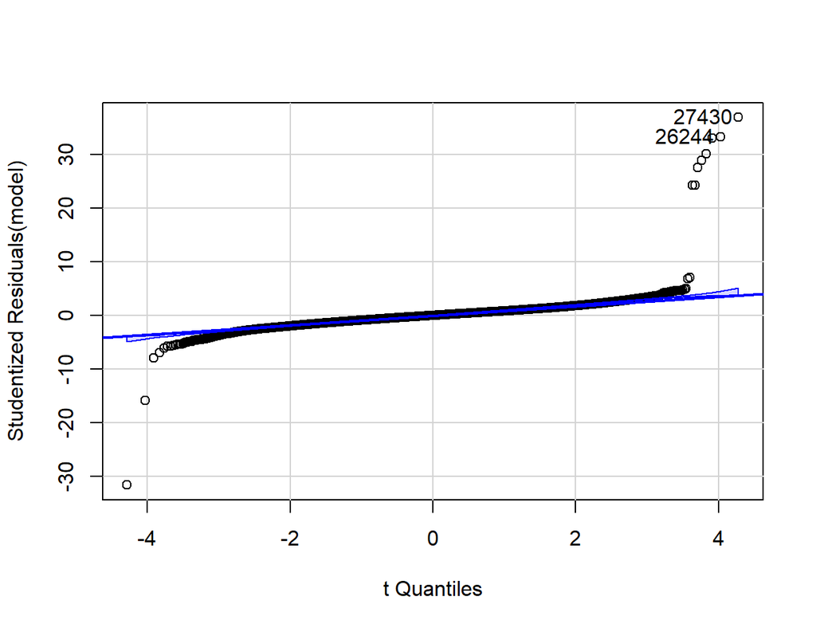

```
## [1] 26244 27430
```

```r
qqPlot(model)
```

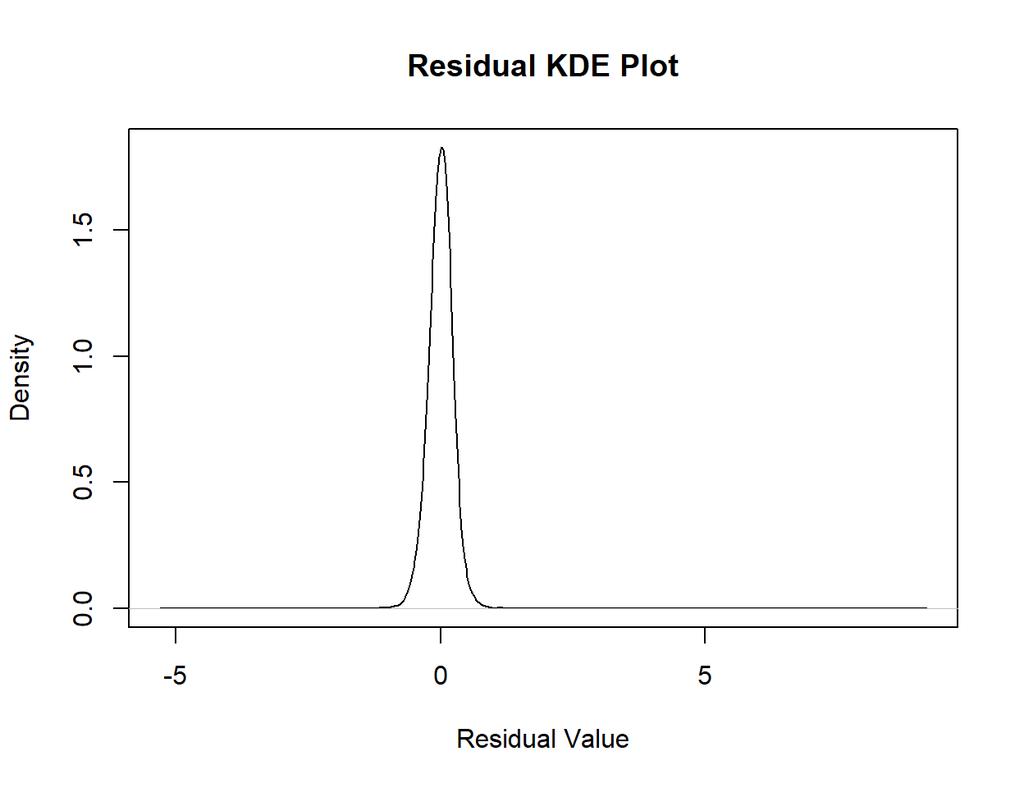

```r
plot(density(model[['residuals']]), main = "Residual KDE Plot",
     xlab = "Residual Value")
```

```r
extract_eq(model, use_coefs = TRUE, wrap = TRUE)
```

$$\begin{aligned}
\operatorname{\widehat{log(price)}} &= 1.39 - 0.47(\operatorname{carat}) + 0.96(\operatorname{x}) + 0.02(\operatorname{y})\ + \\
&\quad 0.19(\operatorname{z}) + 0.11(\operatorname{cut}_{\operatorname{Good}}) + 0.15(\operatorname{cut}_{\operatorname{Very\ Good}}) + 0.11(\operatorname{cut}_{\operatorname{Premium}})\ + \\
&\quad 0.2(\operatorname{cut}_{\operatorname{Ideal}}) + 0.13(\operatorname{color}_{\operatorname{I}}) + 0.24(\operatorname{color}_{\operatorname{H}}) + 0.38(\operatorname{color}_{\operatorname{G}})\ + \\
&\quad 0.4(\operatorname{color}_{\operatorname{F}}) + 0.41(\operatorname{color}_{\operatorname{E}}) + 0.44(\operatorname{color}_{\operatorname{D}})
\end{aligned}$$

This is the equation for our model.

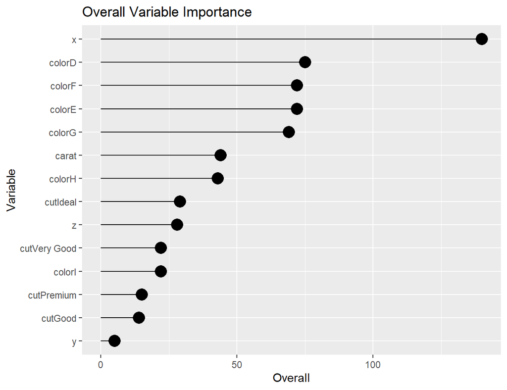

```r
imp <- varImp(model) %>%
  rownames_to_column("Variable") %>%
  mutate(Variable = as.factor(Variable), Overall = as.integer(Overall))

imp$Variable <- reorder(imp$Variable, imp$Overall)


ggplot(imp, aes(x = Overall, y = Variable)) +
  geom_segment(aes(y = Variable, yend = Variable, x = 0, xend = Overall)) +
  geom_point(size = 5, color = "black") +
  labs(title = "Overall Variable Importance")
```

And this shows which variables are the most important to determining a diamonds price.